# Madison Weather

Bret Larget

This R Markdown document includes contributions from Professor Jessi Kehe.

# Madison Weather Overview

- We will be working with data set containing weather data on Madison collect over a number of years from different weather stations.
- In addition to investigating different scientific questions on the data, we will also be learning about the [`dplyr` package](https://dplyr.tidyverse.org/) from `tidyverse` which is “a grammar of data manipulation.”

## Overview of Madison Weather Data

> The source of the data for this week is from the National Oceanic and Atmospheric Administration (NOAA) of the United States.
- See [CNCS Chapter 7](https://bookdown.org/bret_larget/stat-240-case-studies/madison-weather.html) for more information.
- The data set described here includes data through December 31, 2021.
- The data file is `madison-weather-1869-2021.csv`, and the variable descriptions are provided below.

STATION: unique code for the weather station  
NAME: station name  
LATITUDE: station latitude  
LONGITUDE: station longitude  
ELEVATION: station elevation (feet above sea level)  
DATE: date of observations  
PRCP: precipitation (inches, water)  
SNOW: snow fall (inches)  
SNWD: snow depth (inches)  
TAVG: daily average air temperature (degrees Fahrenheit)  
TMAX: maximum air temperature (degrees Fahrenheit)  
TMIN: minimum air temperature (degrees Fahrenheit)

### Import Data

- The data file has one row for each date and weather station.
- The following block of code will read in the data.
  - We specify the types of data in each column.
  - This prevents an error where some variables with many initial rows of contain missing data and are set to be logical instead of numeric.

```r
## Read in the data
## Specify the type
## This is needed to avoid issues for columns where first 1000 rows are all missing
##   and the type is set to logical

mw_original = read_csv("../../data/madison-weather-1869-2021.csv",
                       col_types = cols(
                         STATION = col_character(),
                         NAME = col_character(),
                         LATITUDE = col_double(),
                         LONGITUDE = col_double(),
                         ELEVATION = col_double(),
                         DATE = col_date(format = ""),
                         PRCP = col_double(),
                         SNOW = col_double(),
                         SNWD = col_double(),
                         TAVG = col_double(),
                         TMAX = col_double(),
                         TMIN = col_number()))
dim(mw_original)
```

```
## [1] 104016     12
```

```r
head(mw_original)
```

```
## # A tibble: 6 × 12
##   STATION NAME  LATIT…¹ LONGI…² ELEVA…³ DATE        PRCP  SNOW  SNWD  TAVG  TMAX
##   <chr>   <chr>   <dbl>   <dbl>   <dbl> <date>     <dbl> <dbl> <dbl> <dbl> <dbl>
## 1 USC004… UW A…    43.0   -89.4    265. 1971-10-01  0       NA    NA    NA    88
## 2 USC004… UW A…    43.0   -89.4    265. 1971-10-02  0       NA    NA    NA    87
## 3 USC004… UW A…    43.0   -89.4    265. 1971-10-03  0.15    NA    NA    NA    86
## 4 USC004… UW A…    43.0   -89.4    265. 1971-10-04  0.02    NA    NA    NA    70
## 5 USC004… UW A…    43.0   -89.4    265. 1971-10-05  0.01    NA    NA    NA    69
## 6 USC004… UW A…    43.0   -89.4    265. 1971-10-06  0.25    NA    NA    NA    72
## # … with 1 more variable: TMIN <dbl>, and abbreviated variable names ¹LATITUDE,
## #   ²LONGITUDE, ³ELEVATION
```

## Transform Data

- I do not like using all capital letters for the variable names.
  - Let’s change names using the `rename()` function.
- We will save the changed data in an object named `mw`.

```r
## rename the variables
mw = mw_original %>%
  rename(station = STATION,
         name = NAME,
         latitude = LATITUDE,
         longitude = LONGITUDE,
         elevation = ELEVATION,
         date = DATE,
         prcp = PRCP,
         snow = SNOW,
         snow_depth = SNWD,
         tavg = TAVG,
         tmax = TMAX,
         tmin = TMIN)
```

- The values in the `name` variable are long and unwieldly.
- Change them using the `recode()` function inside of `mutate()`
  - We use `mutate()` to create new variables or modify existing variables
  - `recode()` is different than most **tidyverse** variables which change values
  - Most use the idiom `new = old`, but `recode()` is backwards.
  - This is an oddity of the language you just need to remember (or look up when there is an unexpected error).

```r
mw = mw %>%
  mutate(name = recode(name,
                       `UW ARBORETUM MADISON, WI US` = "Arboretum",
                       `CHARMANY FARM, WI US` = "Charmany",
                       `MADISON DANE CO REGIONAL AIRPORT, WI US` = "Airport",
                       `MADISON WEATHER BUREAU CITY, WI US` = "Bureau"))
```

## Weather Stations

- Some of the variables refer to the weather stations and do not change.
- Let’s make a summary with one row per weather station where we can specify:
  - The station code
  - The earliest date included
  - The latest date included
  - The number of dates included in the data set
  - The number of dates that are missing
- Here is the strategy:
  - use `group_by()` to do the calculations for each weather station separately
  - compare the total number of possible dates from the earliest to latest dates with the actual number of values for each

```r
stations = mw %>%
  select(station, name, latitude, longitude, elevation, date) %>%
  group_by(station, name, latitude, longitude, elevation) %>%
  summarize(first_date = min(date),
            last_date = max(date),
            n = n(),
            possible = as.numeric(last_date - first_date) + 1,
            missing = possible - n)
stations
```

```
## # A tibble: 4 × 10
## # Groups:   station, name, latitude, longitude [4]
##   station     name   latit…¹ longi…² eleva…³ first_date last_date      n possi…⁴
##   <chr>       <chr>    <dbl>   <dbl>   <dbl> <date>     <date>     <int>   <dbl>
## 1 USC00470273 Arbor…    43.0   -89.4    265. 1971-10-01 2021-12-31 18179   18355
## 2 USC00471416 Charm…    43.1   -89.5    319. 1959-08-01 2021-12-31 21410   22799
## 3 USC00474966 Bureau    43.1   -89.4    297. 1869-01-01 1963-05-31 34384   34483
## 4 USW00014837 Airpo…    43.1   -89.3    262. 1939-10-01 2021-12-31 30043   30043
## # … with 1 more variable: missing <dbl>, and abbreviated variable names
## #   ¹latitude, ²longitude, ³elevation, ⁴possible
```

- The official weather station was the Madison Weather Bureau from January 1, 1869 until September 30, 1939 and then the Airport from October 1, 1939 to the present.
- The weather stations at the Arboretum and Charmany Farms have a great deal of missing data.
- We will modify the `mw` data set by:
  - eliminating the station-specific variables
  - eliminating observations from the Arboretum and Charmany Farms
  - arranging by date
- We can create an official Madison weather data set with one observation per date

```r
mw = mw %>%
  select(name, date, prcp, snow, snow_depth, tmin, tmax, tavg) %>%
  filter(name == "Airport" | name == "Bureau") %>%
  arrange(date, name)


official = mw %>%
  filter(name == "Airport" | (name == "Bureau" & date < ymd("1939-10-01")))
```

- Let’s redo the missing data calculations for the official data

```r
official_stations = official %>%
  select(name, date) %>%
  group_by(name) %>%
  summarize(first_date = min(date),
            last_date = max(date),
            n = n(),
            possible = as.numeric(last_date - first_date) + 1,
            missing = possible - n)
official_stations
```

```
## # A tibble: 2 × 6
##   name    first_date last_date      n possible missing
##   <chr>   <date>     <date>     <int>    <dbl>   <dbl>
## 1 Airport 1939-10-01 2021-12-31 30043    30043       0
## 2 Bureau  1869-01-01 1939-09-30 25832    25839       7
```

- The official record is missing just seven days.
- We will explore this next.

## Missing Data

- There are seven missing dates in the official records.
- In addition, there may be some missing data among the precipation and temperature data.
- We will first add in the missing dates with missing data for all variables
- Then, we will count missing data in each column of data.
- To add missing dates, we will create a data frame with all dates from January 1, 1869 through September 30, 1939, and then join it to the official weather data set.

```r
## Create a temporary data file
temp = tibble(
  date = seq(ymd("1869-01-01"), ymd("1939-09-30"), 1),
  name = "Bureau")

## join with the official data set
## show this adds the seven missing dates
nrow(official)
```

```
## [1] 55875
```

```r
official = official %>%
  full_join(temp, by = c("name", "date"))

## Note there are now seven more dates added
nrow(official)
```

```
## [1] 55882
```

```r
## Eliminate the temporary data set
rm(temp)
```

- Next, count the missing observations in each variable
- We create a function to count missing observations.
- We cannot use comparisons such as `==` to compare with `NA`.
- Instead, use `is.na()`.
- We will learn more about writing functions later in the course.

```r
count_na = function(x)
{
  return( sum(is.na(x)) )
}
```

- Do the summary of missing data

```r
official_summary = official %>%
  summarize(prcp_na = count_na(prcp),
            snow_na = count_na(snow),
            depth_na = count_na(snow_depth),
            tmax_na = count_na(tmax),
            tmin_na = count_na(tmin),
            tavg_na = count_na(tavg))

official_summary
```

```
## # A tibble: 1 × 6
##   prcp_na snow_na depth_na tmax_na tmin_na tavg_na
##     <int>   <int>    <int>   <int>   <int>   <int>
## 1      18    5522    10589      10      11   50011
```

- There is a lot of missing data for average temperatures.
- We can recalculate these as the average of the `tmax` and `tmin` variables.
- There is minimal missing data for precipitation or maximum or minimum temperatures.
  - Summaries of these variables over the years after dropping missing data are not likely to be too inaccurate
- Snow and snow depth data has a fair amount missing.
  - Much of this is because the data was not recorded at the beginning of the collection period.

#### Applying the same function to multiple columns

- The previous R chunk created a summary by calling the same function on several columns of data.
- With only six columns, this was not too awful, but imagine if there were more than 100 columns; there must be a better way to apply the same function to multiple columns without typing their names one by one
- We can use `across()`

```r
official_summary2 = official %>%
  summarize(across(prcp:tavg, count_na))

official_summary2
```

```
## # A tibble: 1 × 6
##    prcp  snow snow_depth  tmin  tmax  tavg
##   <int> <int>      <int> <int> <int> <int>
## 1    18  5522      10589    11    10 50011
```

#### Snow data

- Let’s take a closer look at the pattern of missing data for the two snow variables

```r
official %>%
  select(name, date, snow) %>%
  drop_na() %>%
  summarize(first_snow = min(date))
```

```
## # A tibble: 1 × 1
##   first_snow
##   <date>
## 1 1884-01-01
```

```r
official %>%
  select(name, date, snow_depth) %>%
  drop_na() %>%
  summarize(first_snow_depth = min(date))
```

```
## # A tibble: 1 × 1
##   first_snow_depth
##   <date>
## 1 1884-06-01
```

- If we analyze the snow data, we will need to use a different time range.
- Also, some NA snow totals in the summer or when precipitation is zero may really be zero and not missing.
- We can count missing data by month and then plot the results

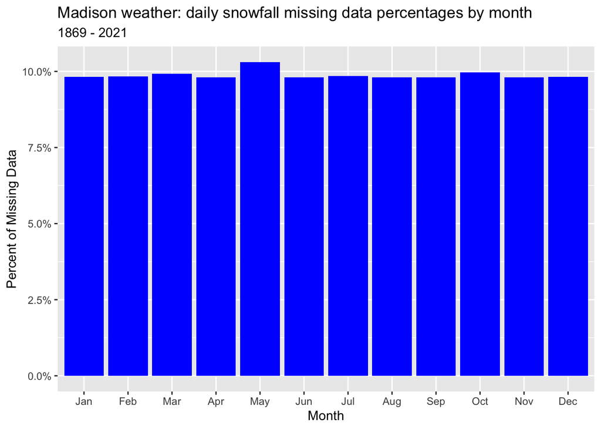

```r
snow_sum = official %>%
  mutate(month = month(date, label = TRUE)) %>% ## here, month() is a lubridate command
  group_by(month) %>%
  summarize(n = n(),
            missing = count_na(snow),
            p = missing / n)

ggplot(snow_sum, aes(x = month, y = p)) +
  geom_col(fill = "blue") +
  scale_y_continuous(labels = scales::percent) +
  xlab("Month") +
  ylab("Percent of Missing Data") +
  ggtitle("Madison weather: daily snowfall missing data percentages by month",
          subtitle = "1869 - 2021")
```

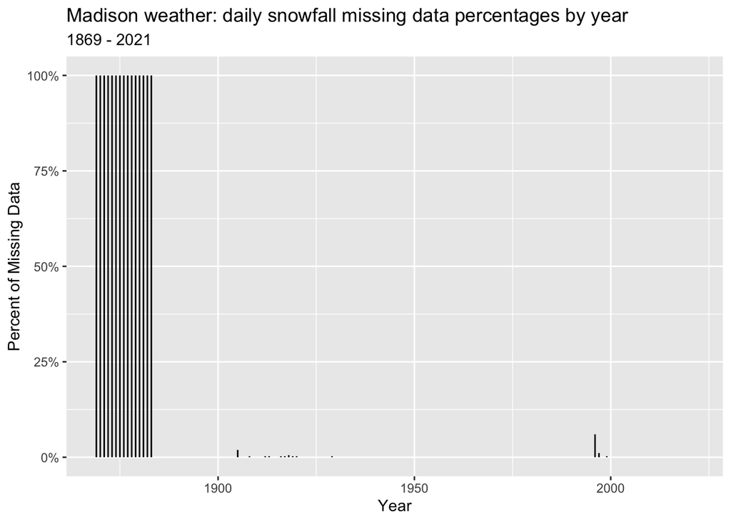

```r
snow_sum2 = official %>%
  mutate(year = year(date)) %>%
  group_by(year) %>%
  summarize(n = n(),
            missing = count_na(snow),
            p = missing / n)

ggplot(snow_sum2, aes(x = year, y = p)) +
  geom_segment(aes(x = year, xend = year, yend = 0 )) +
  scale_y_continuous(labels = scales::percent) +
  xlab("Year") +
  ylab("Percent of Missing Data") +
  ggtitle("Madison weather: daily snowfall missing data percentages by year",
          subtitle = "1869 - 2021")
```

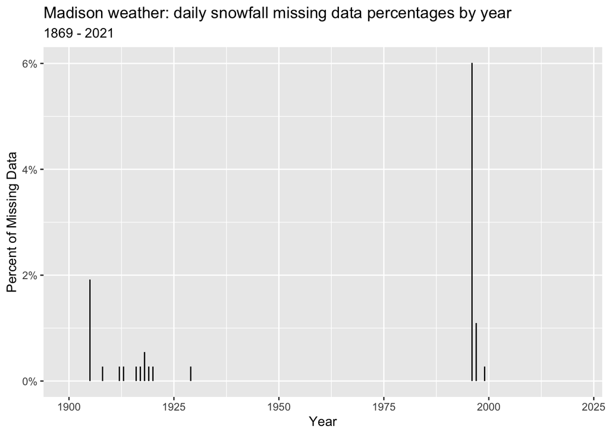

```r
## Years since 1900
snow_sum2 %>%
  filter(year > 1899) %>%
ggplot(aes(x = year, y = p)) +
  geom_segment(aes(x = year, xend = year, yend = 0 )) +
  scale_y_continuous(labels = scales::percent) +
  xlab("Year") +
  ylab("Percent of Missing Data") +
  ggtitle("Madison weather: daily snowfall missing data percentages by year",
          subtitle = "1869 - 2021")
```

## Repair average temperature

```r
official = official %>%
  mutate(tavg = (tmin + tmax) / 2)
```

## Write files

- It will be helpful to write the modified official weather data into a file so that we do not need to redo the data transformations each time

```r
write_csv(official, "../../data/madison-weather-official-1869-2021.csv")
```